# Series Temporales ventas Apple

Garcia Giron A

15/11/2020

# Índice

### 1. Carga de datos

### 2. Representación Gráfica

### 3. Componentes de la serie

### 4. Modelo ARIMA

### 5. Modelo ETS

Carga de librerias

```r
library(readr)
require(forecast) # Transform to zoo data
require(xts) # Create a XTS object
```

```r
require(ggplot2) # graphs
library(ggfortify) # graphs
```

Carga de datos

```r
rawData <- read.csv2("../data/IngresosApple.csv", sep=";")
rawData
```

```
##    Trimestre Ingresos
## 1    Q2 2008     7980
## 2    Q3 2008     7561
## 3    Q4 2008    11520
## 4    Q1 2009    11880
## 5    Q2 2009     9084
## 6    Q3 2009     9734
## 7    Q4 2009    12207
## 8    Q1 2010    15683
## 9    Q2 2010    13499
## 10   Q3 2010    15700
## 11   Q4 2010    20343
## 12   Q1 2011    26741
## 13   Q2 2011    24667
## 14   Q3 2011    28571
```

[output cut: 24 more lines]

```r
#Transformamos el DataFrame para que se pueda manejar como SAerie Temporal
rawVent <- rawData$Ingresos
rawDate <- seq(as.Date("2008/04/01"), as.Date("2017/07/01"), by = "quarter")
#Actamos las variables por separado
```

```r
# Creamos un objeto XTS, idoneo en sT
xVent = xts(rawVent,order.by=rawDate)
xVent
```

```
##             [,1]
## 2008-04-01  7980
## 2008-07-01  7561
## 2008-10-01 11520
## 2009-01-01 11880
## 2009-04-01  9084
## 2009-07-01  9734
## 2009-10-01 12207
## 2010-01-01 15683
## 2010-04-01 13499
## 2010-07-01 15700
## 2010-10-01 20343
## 2011-01-01 26741
## 2011-04-01 24667
## 2011-07-01 28571
## 2011-10-01 28270
## 2012-01-01 46333
## 2012-04-01 39186
## 2012-07-01 35023
## 2012-10-01 35966
## 2013-01-01 54512
## 2013-04-01 43603
## 2013-07-01 35323
## 2013-10-01 37472
## 2014-01-01 57594
## 2014-04-01 45646
## 2014-07-01 37432
## 2014-10-01 42123
## 2015-01-01 74599
## 2015-04-01 58010
## 2015-07-01 49605
## 2015-10-01 51501
## 2016-01-01 75324
## 2016-04-01 50557
## 2016-07-01 42358
## 2016-10-01 46852
## 2017-01-01 78351
## 2017-04-01 52896
## 2017-07-01 45408
```

```r
# ordenamos por datos trimestrales ya que nuestra data tiene esos espacios discretos delimitados

xVent = to.quarterly(xVent)
zVent = as.zoo(xVent$xVent.Close)

#renombramos por mejora
names(zVent)="Ventas_apple"
```

## 2. Representacion Gráfica

Antes de comenzar cualquier análisis de Series Temporales debemos cerciorarnos de la calidad de la observacion y debemos determinar a priori visualmente si la serie es estacionaria, o no estacionaria ya lo sea por accion de la media y/o la varianza.

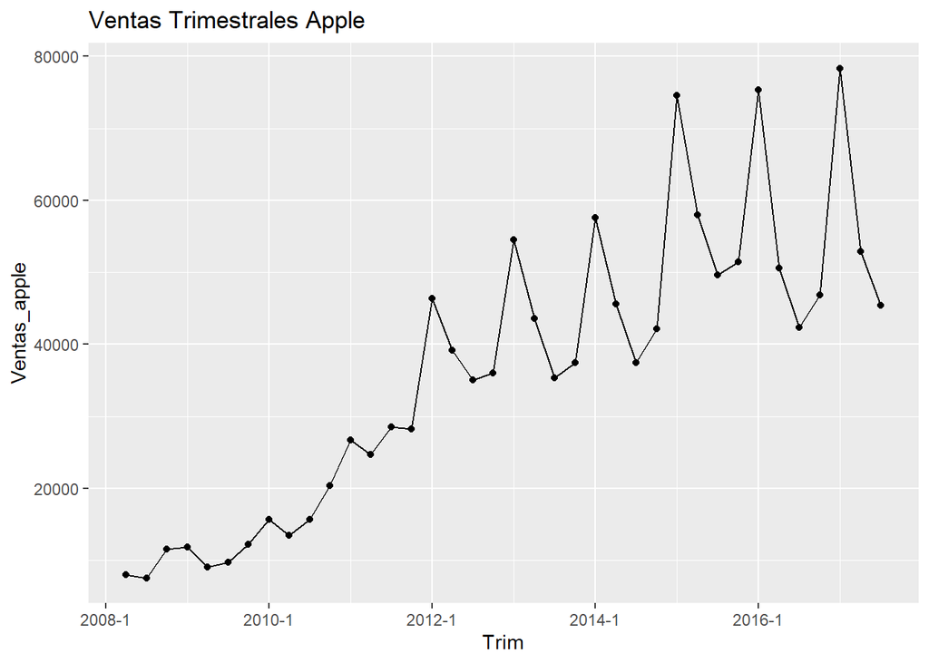

```r
nuevo_dataframe <- data.frame(value = as.vector(zVent),
                     time = time(zVent))
ggplot(nuevo_dataframe)+geom_point(aes(x=time,y=value))+geom_line(aes(x=time,y=value))+ylab("Ventas_apple")+ggtitle("Ventas Trimestrales Apple")+xlab("Trim")
```

Tras ver la gráfica afirmamos que la serie no es estacionaria ni en media ni en varianza.

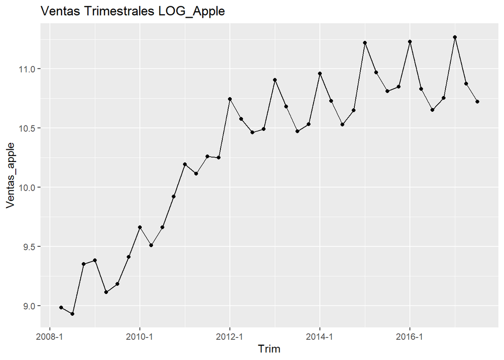

```r
# La transformacion logaritmica es util en estos casos
zlVent=log(zVent)
nuevo_dataframe<- data.frame(value = as.vector(zlVent),
                     time = time(zlVent))
ggplot(nuevo_dataframe)+geom_point(aes(x=time,y=value))+geom_line(aes(x=time,y=value))+ylab("Ventas_apple")+ggtitle("Ventas Trimestrales LOG_Apple")+xlab("Trim")
```

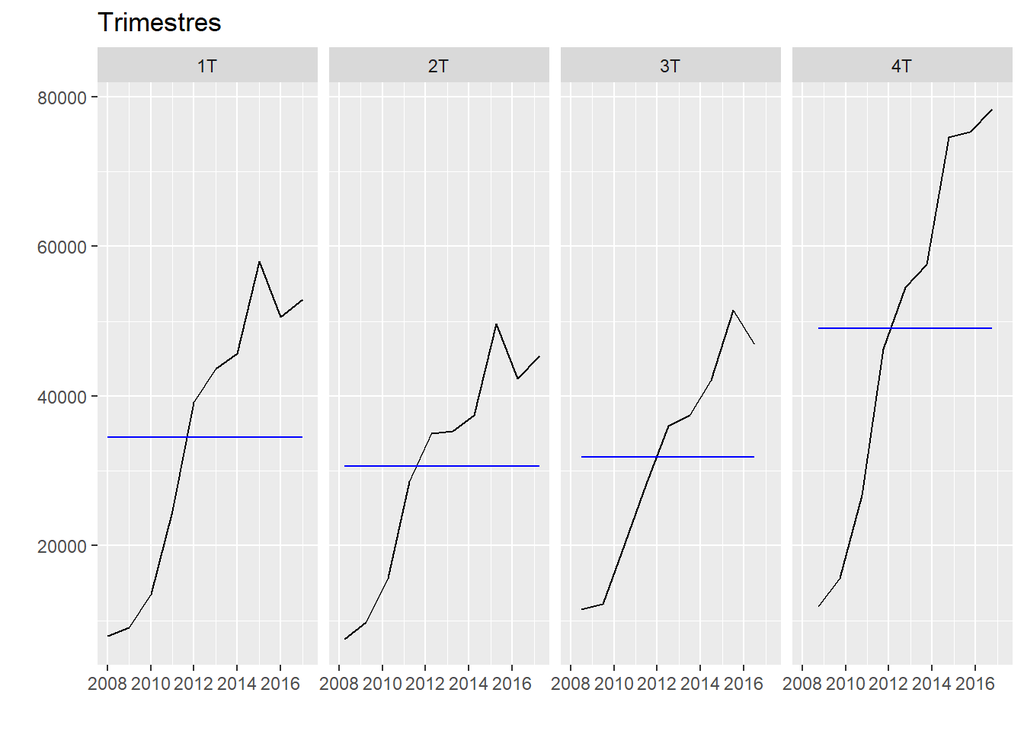

```r
#loas vemos con periodicidad trimestral en el plot
trim_Ventas =ts(coredata(zVent), start = c(2008, 1), frequency = 4)
#grafico con valor trimestral
ggfreqplot(trim_Ventas,freq=4,nrow=1,facet.labeller=c("1T","2T","3T","4T"))+ggtitle("Trimestres")
```

Un análisis gráfico del plot anterior nos permite observar que la tendencia es parecida,no igual, durante los primeros trimestres del año. En el último trimestre vemos que se disparan. no es nuestro cometido buscar la causa que origina esto pero sabemos que en esta fecha del año, al menos en occidente, el consumo se dispara a causa de las fecchas navideñas y en la tecnologia muchos consumidores la ven como un presente ad hoc.

## 3. Componentes de la serie

#trend #seasson #remainder

```r
stl(trim_Ventas[, 1], s.window = "periodic")
```

```
##  Call:
##  stl(x = trim_Ventas[, 1], s.window = "periodic")
##
## Components
##          seasonal     trend   remainder
## 2008 Q1 -1191.515 11987.713 -2816.19786
## 2008 Q2 -6202.795 11054.647  2709.14756
## 2008 Q3 -4388.396 10306.954  5601.44193
## 2008 Q4 11782.720  9712.795 -9615.51515
## 2009 Q1 -1191.515 10313.378   -37.86329
## 2009 Q2 -6202.795 11865.051  4071.74373
## 2009 Q3 -4388.396 12348.763  4246.63276
## 2009 Q4 11782.720 12927.130 -9026.85026
## 2010 Q1 -1191.515 14968.422  -277.90712
## 2010 Q2 -6202.795 18282.820  3619.97453
```

[output cut: 28 more lines]

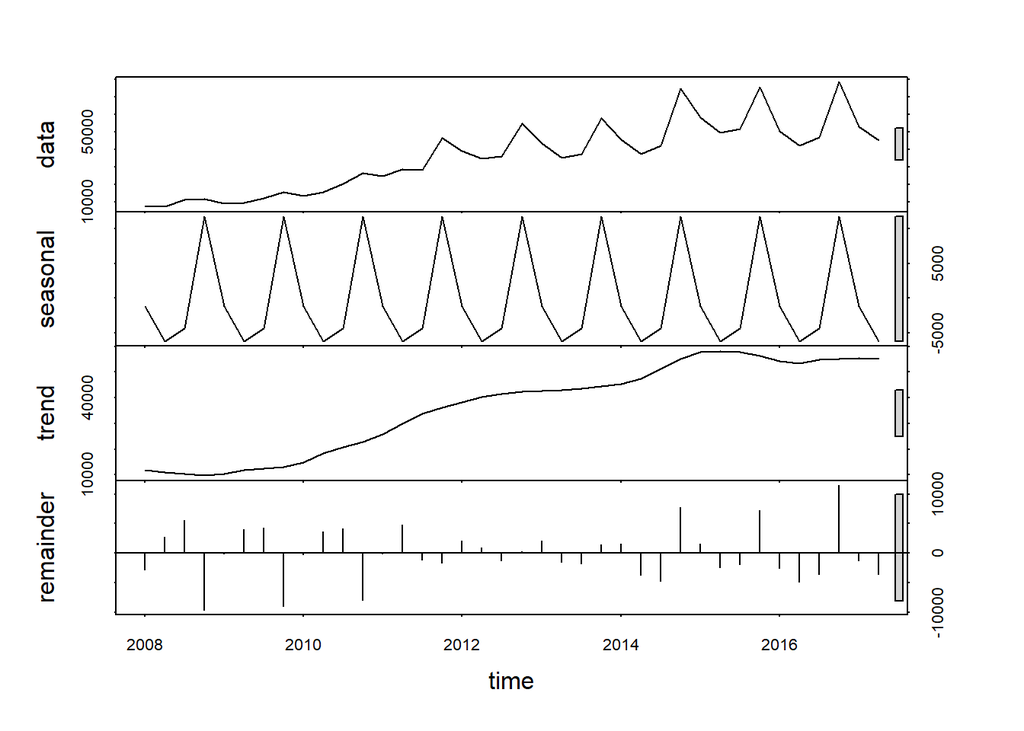

```r
plot(stl(trim_Ventas[, 1], s.window = "periodic"))
```

El grafico anterior sirve para cerciorarnos de que se cumplen o no los supuestos de los modelos ARIMA. debemos eliminar la parte no estacionaria del modelo para simplificar su analitica junto con la parte estacional de los datos

Eliminamos trimestres del 2017:

```r
# obviamos del analisis los q1 q2 q3 trimestres de 2017
cOmit=3

#nueva dimension
nObs=length(zVent)

#modelo Alfa
oVentas <- window(zVent,start=index(zVent[1]),end=index(zVent[nObs-cOmit]))

#pronostico
pVenta <- window(zVent,start=index(zVent[nObs-cOmit+1]),end=index(zVent[nObs]))
pVenta
```

```
##         Ventas_apple
## 2017 Q1        78351
## 2017 Q2        52896
## 2017 Q3        45408
```

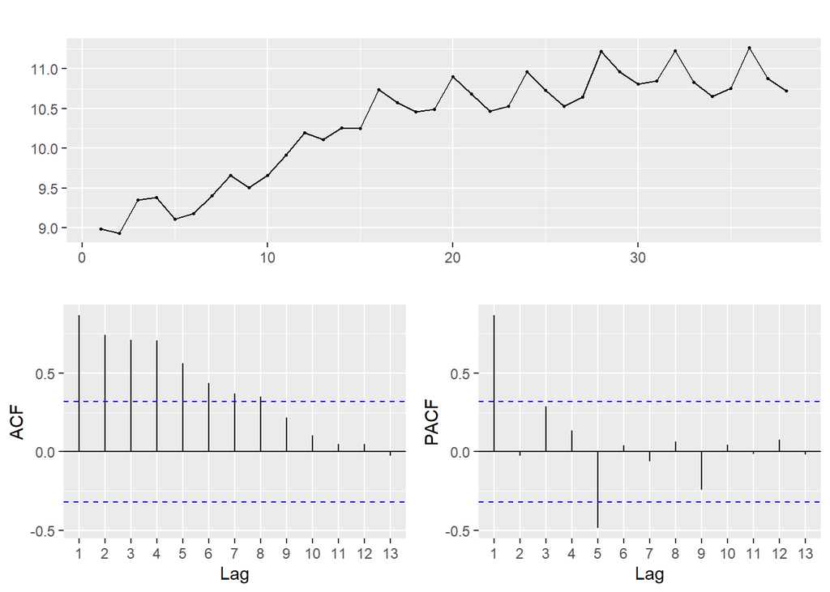

```r
#manipulamos la dif 1
ggtsdisplay(zlVent)
```

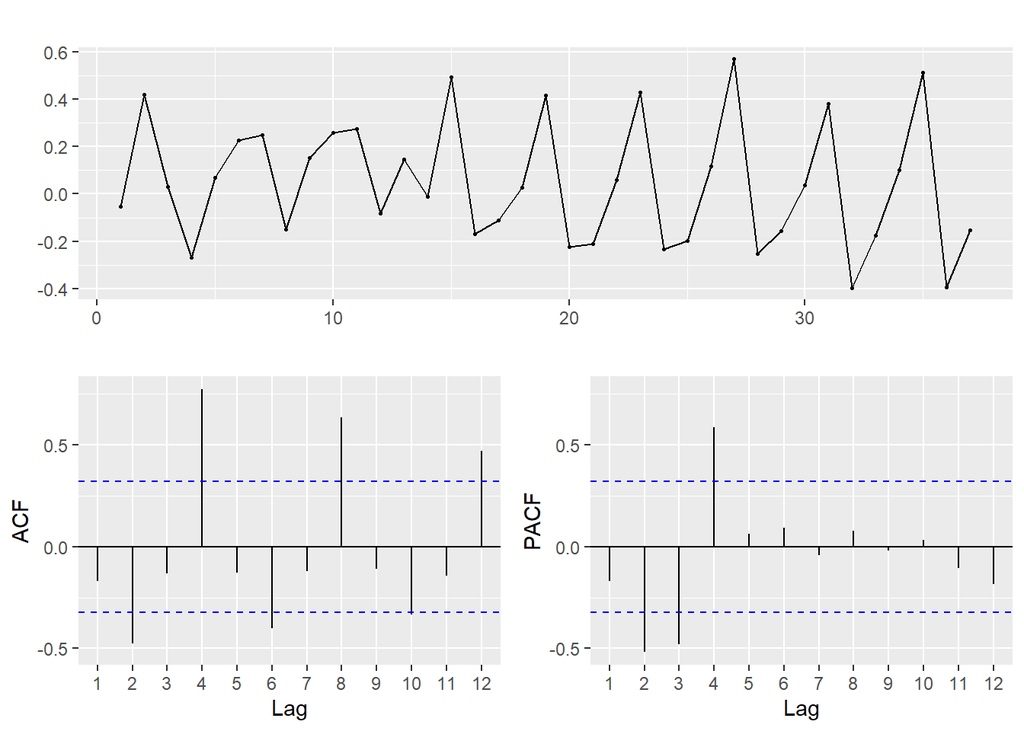

```r
# manipulamos la dif 2
ggtsdisplay(diff(zlVent))
```

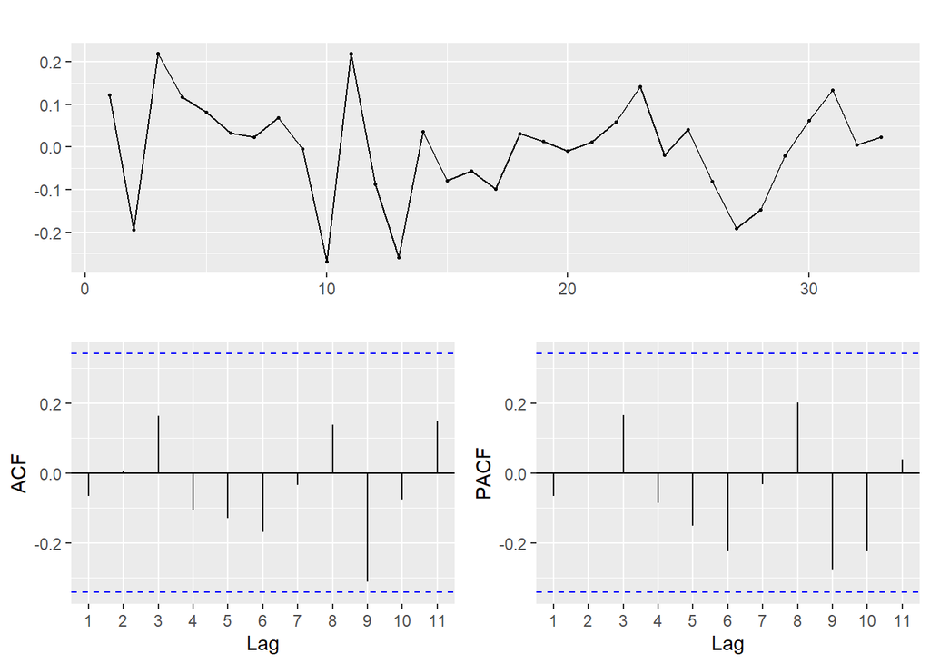

```r
#para ver la distancia entre las dif, yo me entiendo foto movil.
ggtsdisplay(diff(diff(zlVent,4),1))
```

### 4. Modelo ARIMA

```r
# MODELO ARIMA

fit_1 =auto.arima(oVentas,lambda=0)
summary(fit_1)
```

```
## Series: oVentas
## ARIMA(0,1,0)(0,1,0)[4]
## Box Cox transformation: lambda= 0
##
## sigma^2 estimated as 0.01472:  log likelihood=20.72
## AIC=-39.45   AICc=-39.3   BIC=-38.04
##
## Training set error measures:
##                     ME     RMSE      MAE       MPE     MAPE      MASE      ACF1
## Training set -764.5058 4786.405 3054.054 -1.321616 8.284962 0.4406634 0.1269135
```

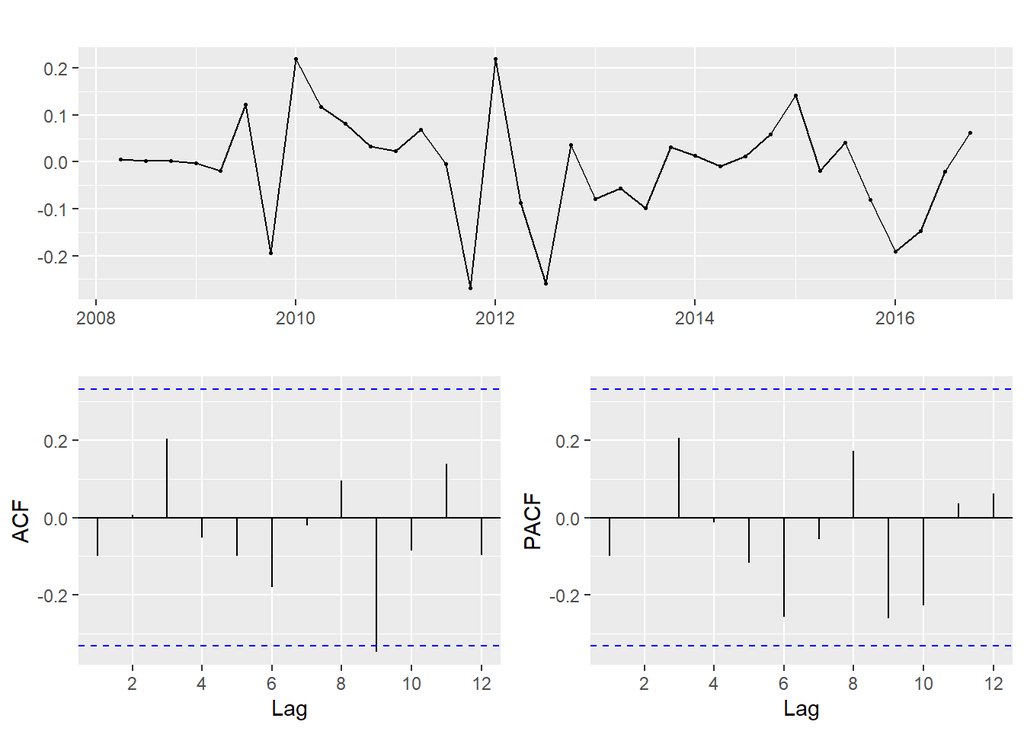

```r
# Analisis del residuo
ggtsdisplay(fit_1$residuals)
```

Asumimos graficamente que los modelos se situan entre las bandas azules a pesar de que ACF roza con cierta notoriedad los límites, en general damos por vñálido el concierto de fluctuaciones.

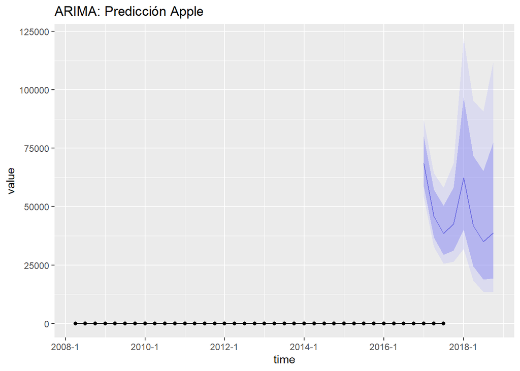

```r
# Prediccion

fVentas.arima = forecast(fit_1)

ggplot(nuevo_dataframe)+geom_point(aes(x=time,y=value))+geom_line(aes(x=time,y=value))+ geom_forecast(fVentas.arima,alpha=0.4)+ggtitle("ARIMA: Predicción Apple")
```

### 5. Modelo ETS

```r
#ETS AUTOMATICO
ets_fit<-ets(oVentas,damped = TRUE)

#forecast model
fVent.ets=forecast(ets_fit)

#Results
summary(fVent.ets)
```

```
##
## Forecast method: ETS(M,Ad,M)
##
## Model Information:
## ETS(M,Ad,M)
##
## Call:
##  ets(y = oVentas, damped = TRUE)
##
##   Smoothing parameters:
##     alpha = 0.4866
##     beta  = 0.4866
##     gamma = 0.5134
##     phi   = 0.8412
##
##   Initial states:
##     l = 7124.7146
##     b = 1557.5091
##     s = 1.246 1.0241 0.8186 0.9113
##
##   sigma:  0.1279
##
##      AIC     AICc      BIC
## 706.7948 715.9615 722.3483
##
## Error measures:
##                    ME     RMSE      MAE      MPE    MAPE     MASE      ACF1
## Training set 336.7763 4012.287 2865.906 1.165156 8.77168 0.413516 0.1371203
##
## Forecasts:
##         Point Forecast     Lo 80     Hi 80      Lo 95     Hi 95
## 2017 Q1       69929.62 58470.251  81388.98  52404.028  87455.21
## 2017 Q2       53001.85 40992.858  65010.84  34635.683  71368.01
## 2017 Q3       47699.77 32676.602  62722.94  24723.817  70675.72
## 2017 Q4       52146.25 30474.789  73817.70  19002.612  85289.88
## 2018 Q1       77165.52 32841.231 121489.81   9377.369 144953.67
## 2018 Q2       57654.24 18635.617  96672.86  -2019.595 117328.07
## 2018 Q3       51287.35 11072.981  91501.71 -10215.219 112789.91
## 2018 Q4       55539.00  5827.416 105250.58 -20488.305 131566.30
```

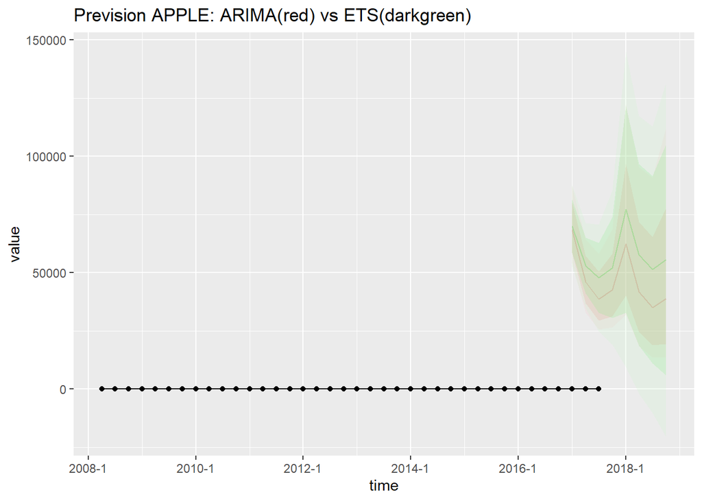

```r
#para compararlos
#juntamos  los tres modelos
ggplot(nuevo_dataframe)+geom_point(aes(x=time,y=value))+
  geom_line(aes(x=time,y=value))+
  geom_forecast(fVentas.arima,color="red",alpha=0.183, plot.conf = FALSE)+
  geom_forecast(fVent.ets,color="darkgreen", alpha=0.183,plot.conf = FALSE)+
  ggtitle("Prevision APPLE: ARIMA(red) vs ETS(darkgreen)")
```

```r
cbind(fVentas.arima$mean,fVent.ets$mean)
```

```
##         fVentas.arima$mean fVent.ets$mean
## 2017 Q1           68524.50       69929.62
## 2017 Q2           45993.21       53001.85
## 2017 Q3           38534.34       47699.77
## 2017 Q4           42622.67       52146.25
## 2018 Q1           62338.78       77165.52
## 2018 Q2           41841.40       57654.24
## 2018 Q3           35055.84       51287.35
## 2018 Q4           38775.11       55539.00
```